# MSBI 32000 Winter 2022 Semester

### Anthropometric Measurements

```r
t.test.b(waist, waist1)
```

```
Response variable: numerical
Explanatory variable: categorical (2 levels)
n_hormone therapy = 1268, y_bar_hormone therapy = 91.8492, s_hormone therapy = 13.7941
n_placebo = 1306, y_bar_placebo = 91.3605, s_placebo = 13.1169
H0: mu_hormone therapy =  mu_placebo
HA: mu_hormone therapy != mu_placebo
t = 0.9206, df = 1267
p_value = 0.3574
```

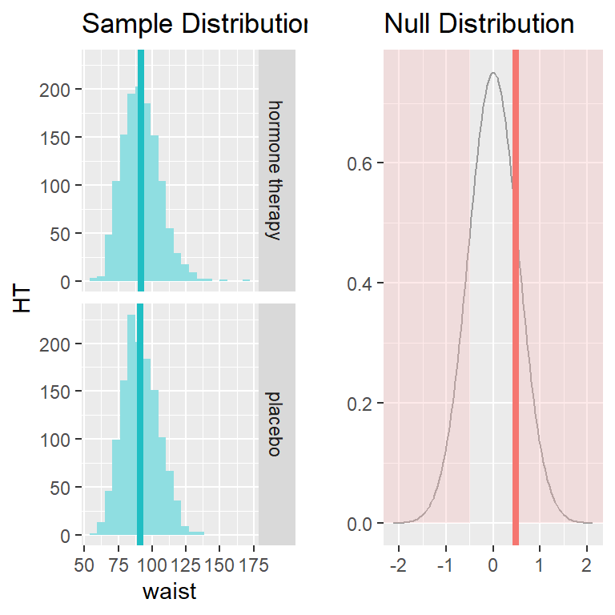

```
$SE
[1] 0.5308498

$df
[1] 1267

$t
[1] 0.9206395

$p_value
[1] 0.3574139

Response variable: numerical
Explanatory variable: categorical (2 levels)
n_hormone therapy = 1268, y_bar_hormone therapy = 90.8652, s_hormone therapy = 13.6419
n_placebo = 1306, y_bar_placebo = 91.1912, s_placebo = 13.3399
H0: mu_hormone therapy =  mu_placebo
HA: mu_hormone therapy != mu_placebo
t = -0.6127, df = 1267
p_value = 0.5402
```

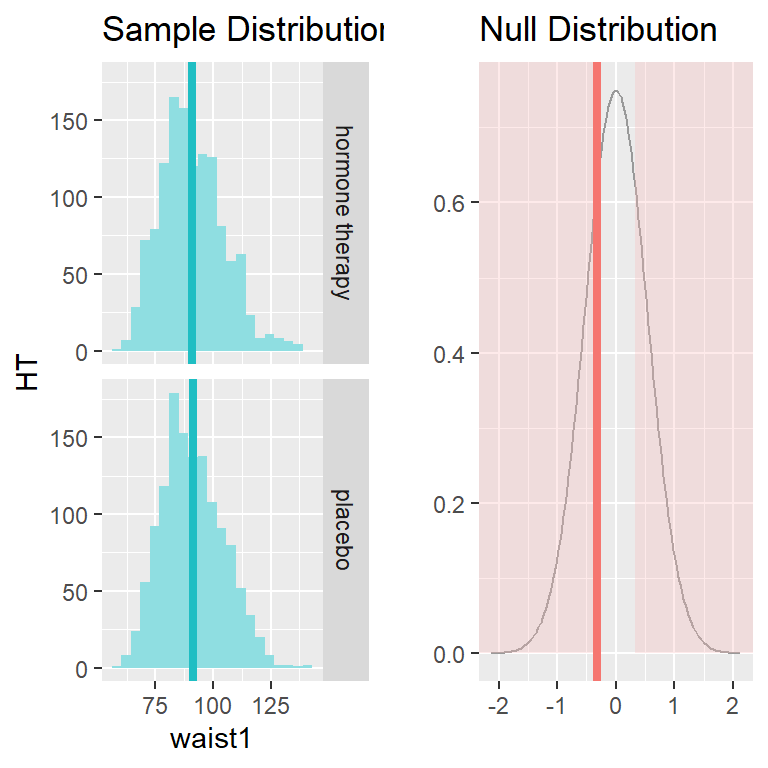

```
$SE
[1] 0.532002

$df
[1] 1267

$t
[1] -0.6127304

$p_value
[1] 0.5401646
```

```r
t.test.b(WHR, WHR1)
```

```
Response variable: numerical
Explanatory variable: categorical (2 levels)
n_hormone therapy = 1268, y_bar_hormone therapy = 0.87, s_hormone therapy = 0.0806
n_placebo = 1306, y_bar_placebo = 0.8678, s_placebo = 0.0776
H0: mu_hormone therapy =  mu_placebo
HA: mu_hormone therapy != mu_placebo
t = 0.714, df = 1267
p_value = 0.4754
```

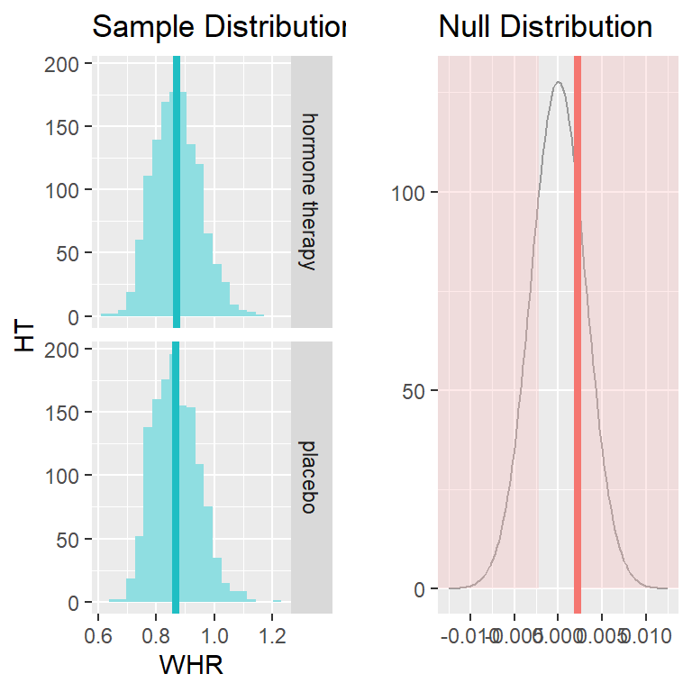

```
$SE
[1] 0.003120744

$df
[1] 1267

$t
[1] 0.7139792

$p_value
[1] 0.4753716

Response variable: numerical
Explanatory variable: categorical (2 levels)
n_hormone therapy = 1268, y_bar_hormone therapy = 0.8664, s_hormone therapy = 0.0789
n_placebo = 1306, y_bar_placebo = 0.8668, s_placebo = 0.076
H0: mu_hormone therapy =  mu_placebo
HA: mu_hormone therapy != mu_placebo
t = -0.102, df = 1267
p_value = 0.9188
```

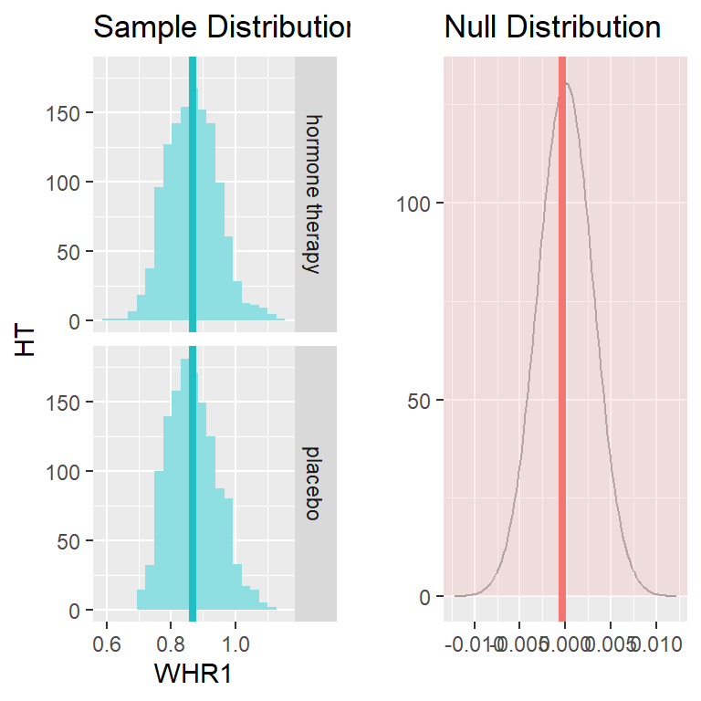

```
$SE
[1] 0.003054311

$df
[1] 1267

$t
[1] -0.1020269

$p_value
[1] 0.9187514
```

```r
t.test.b(BMI, BMI1)
```

```
Response variable: numerical
Explanatory variable: categorical (2 levels)
n_hormone therapy = 1268, y_bar_hormone therapy = 28.5848, s_hormone therapy = 5.4166
n_placebo = 1306, y_bar_placebo = 28.4969, s_placebo = 5.4769
H0: mu_hormone therapy =  mu_placebo
HA: mu_hormone therapy != mu_placebo
t = 0.4093, df = 1267
p_value = 0.6824
```

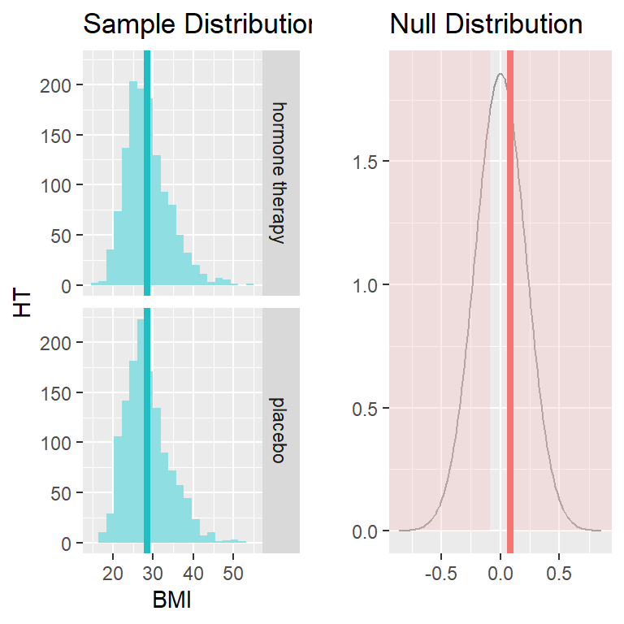

```
$SE
[1] 0.2147259

$df
[1] 1267

$t
[1] 0.409309

$p_value
[1] 0.6823821

Response variable: numerical
Explanatory variable: categorical (2 levels)
n_hormone therapy = 1268, y_bar_hormone therapy = 28.205, s_hormone therapy = 5.4813
n_placebo = 1306, y_bar_placebo = 28.4344, s_placebo = 5.59
H0: mu_hormone therapy =  mu_placebo
HA: mu_hormone therapy != mu_placebo
t = -1.051, df = 1267
p_value = 0.2934
```

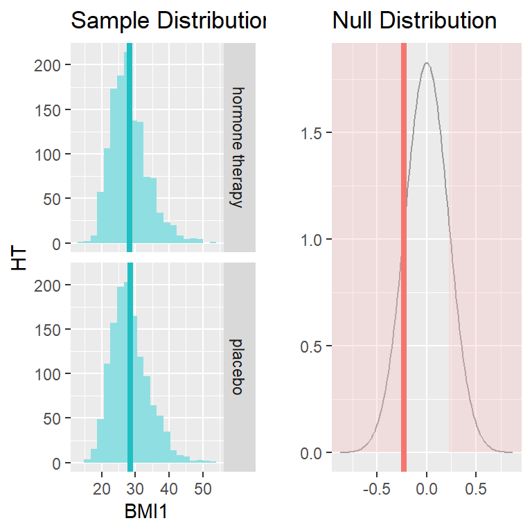

```
$SE
[1] 0.2182236

$df
[1] 1267

$t
[1] -1.051049

$p_value
[1] 0.2934363
```

**RESULTS**

For the anthropometric measurements (measurements and proportions of the body), hormone therapy and control group shows no significant difference both on baseline and follow-up.

## Independent T-tests on Blood Parameter Changes

Here, we further test the significant differences found on the blood test parameters from the first set of t-tests. We calculated the rate of change of the variables and did an independent t-test to evaluate whether the rates of change were significantly different between the two groups.

```r
# Calculate t-test for the change between values at baseline and 1 year of follow-up
# between hormone therapy and placebo group

t.test.diff <- function(var1, var2) {
  val1 <- rlang::call2("$", expr(hers_complete_rows), enexpr(var1))
  val2 <- rlang::call2("$", expr(hers_complete_rows), enexpr(var2))
  diff <- (eval(val2) - eval(val1)) / eval(val1)
  varname <- paste0(rlang::as_string(enexpr(var1)), "_diff")

  hers_complete_rows[[varname]] <- diff
  f <- rlang::call2(
    expr(statsr::inference),
    sym(varname),
    x = expr(HT),
    data = expr(hers_complete_rows),
    type = "ht",
    statistic = "mean",
    method = "theoretical",
    alternative = "twosided"
  )
  eval(f)
}
```

```r
t.test.diff(tchol, tchol1)
```

```
Response variable: numerical
Explanatory variable: categorical (2 levels)
n_hormone therapy = 1268, y_bar_hormone therapy = -0.0448, s_hormone therapy = 0.1534
n_placebo = 1306, y_bar_placebo = -0.0122, s_placebo = 0.1556
H0: mu_hormone therapy =  mu_placebo
HA: mu_hormone therapy != mu_placebo
t = -5.3509, df = 1267
p_value = < 0.0001
```

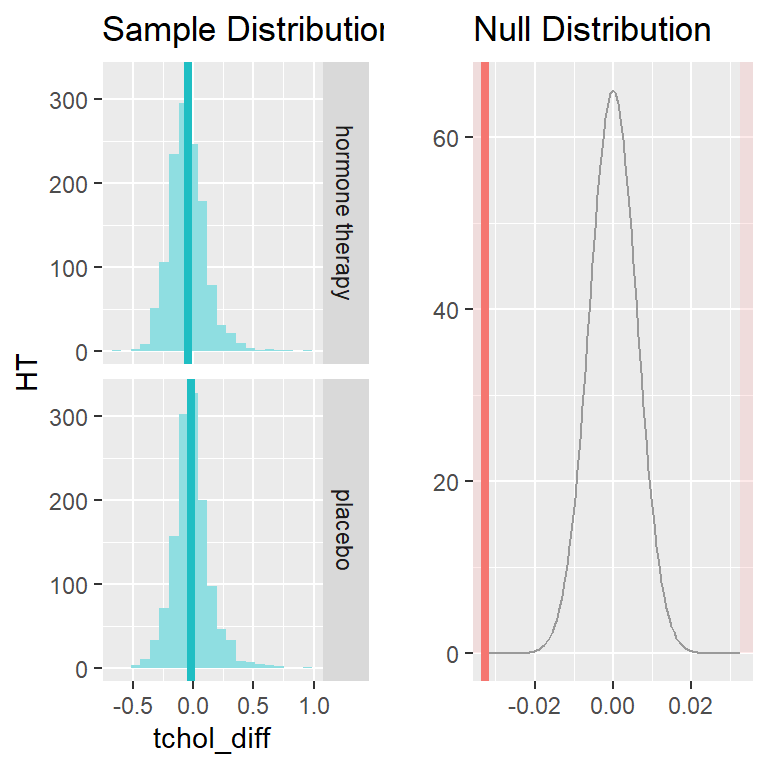

```r
t.test.diff(LDL, LDL1)
```

```
Response variable: numerical
Explanatory variable: categorical (2 levels)
n_hormone therapy = 1268, y_bar_hormone therapy = -0.1204, s_hormone therapy = 0.2228
n_placebo = 1306, y_bar_placebo = -0.0114, s_placebo = 0.2361
H0: mu_hormone therapy =  mu_placebo
HA: mu_hormone therapy != mu_placebo
t = -12.053, df = 1267
p_value = < 0.0001
```

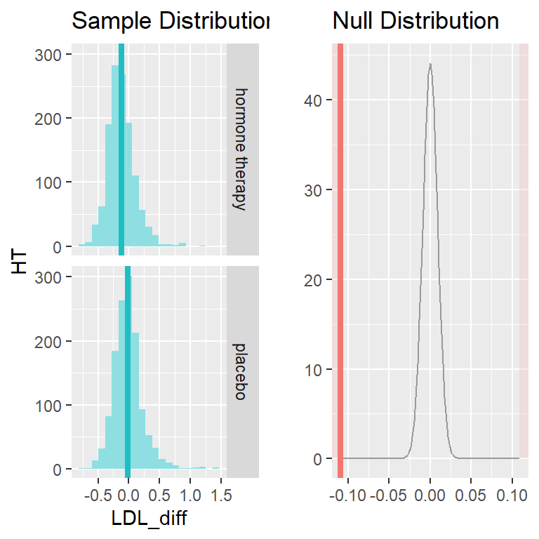

```r
t.test.diff(HDL, HDL1)
```

```
Response variable: numerical
Explanatory variable: categorical (2 levels)
n_hormone therapy = 1268, y_bar_hormone therapy = 0.1026, s_hormone therapy = 0.2092
n_placebo = 1306, y_bar_placebo = -0.0079, s_placebo = 0.1816
H0: mu_hormone therapy =  mu_placebo
HA: mu_hormone therapy != mu_placebo
t = 14.2901, df = 1267
p_value = < 0.0001
```

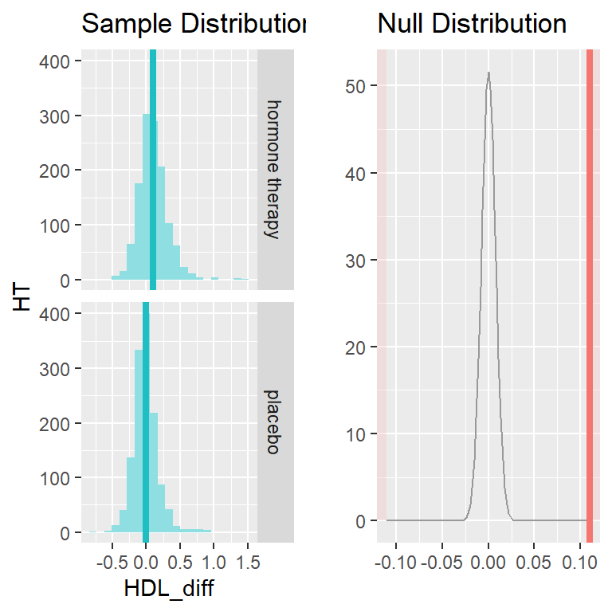

```r
t.test.diff(TG,TG1)
```

```
Response variable: numerical
Explanatory variable: categorical (2 levels)
n_hormone therapy = 1268, y_bar_hormone therapy = 0.1467, s_hormone therapy = 0.4277
n_placebo = 1306, y_bar_placebo = 0.0619, s_placebo = 0.384
H0: mu_hormone therapy =  mu_placebo
HA: mu_hormone therapy != mu_placebo
t = 5.2839, df = 1267
p_value = < 0.0001
```

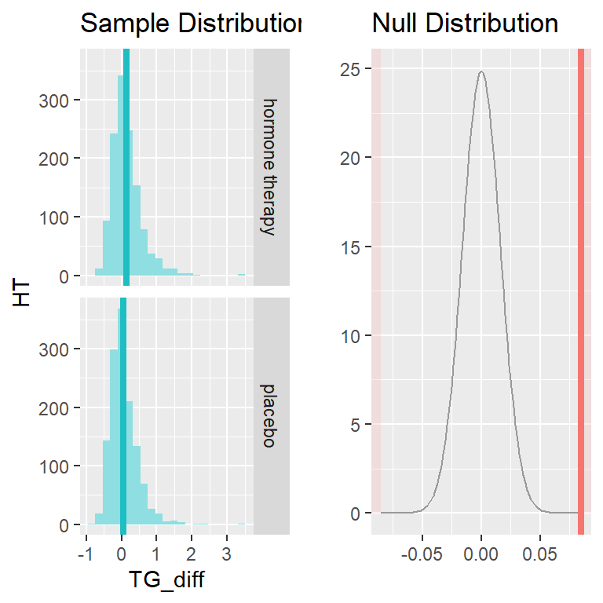

```r
t.test.diff(glucose, glucose1)
```

```
Response variable: numerical
Explanatory variable: categorical (2 levels)
n_hormone therapy = 1268, y_bar_hormone therapy = 0.0335, s_hormone therapy = 0.2737
n_placebo = 1306, y_bar_placebo = 0.0599, s_placebo = 0.2317
H0: mu_hormone therapy =  mu_placebo
HA: mu_hormone therapy != mu_placebo
t = -2.6412, df = 1267
p_value = 0.0084
```

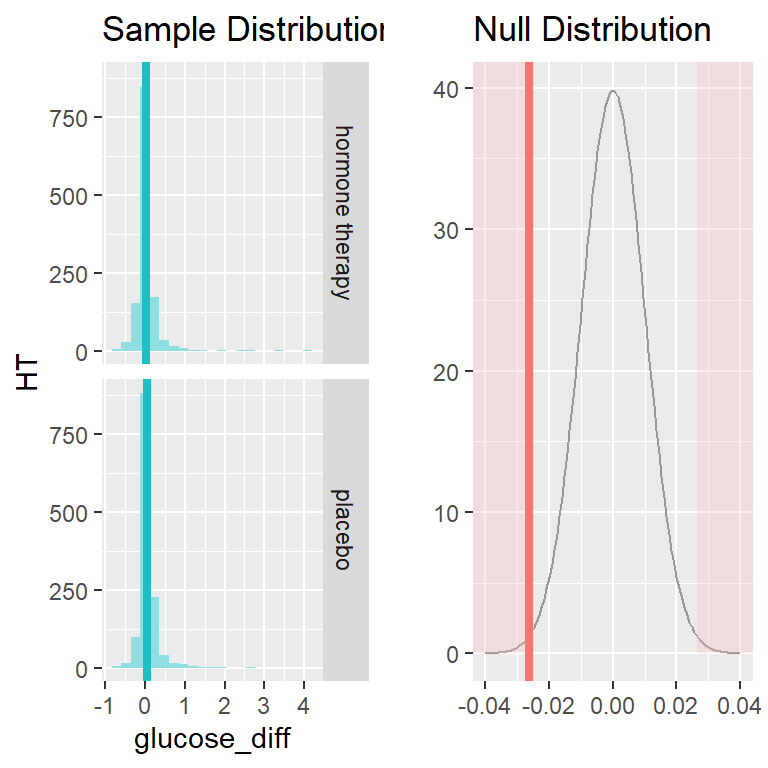

**RESULTS**

# Discussion

We found that the subjects were evenly distributed by demographics between the two study arms, which was expected from a randomized trial. However (based on our barplots and information from the paper), about 89% of the subjects were white women, which may suggest that this study was not representative of all subjects who may undertake this therapy.

Moreover, we found that the outcome of the measured blood parameters (total cholesterol, HDL, LDL, triglycerides, and glucose) had no difference at baseline but by one year of follow-up, there were significant differences between the two groups. The direction of changes seem to be positive for the hormone therapy group where:

- Total Cholesterol and LDL decreased significantly more in the hormone therapy group
- HDL increased significantly more the hormone therapy group.
- Fating glucose increased significantly less in the hormone therapy group.

However, the positive changes were not consistent because triglyceride values were seen to increase significantly more in the hormone therapy group.

It is important to note, that we may not conclude the effect of the therapy on coronary heart disease outcomes based solely on this data. These findings suggest that the therapy did not incur any harm on the subjects (based on the blood parameters) by one year of follow-up and may allow the study to progress. The effect of the therapy on coronary heart disease outcomes shall be made based on follow-up observations, with variable recording coronary heart disease events on the subjects.

# Conclusion

To conclude we need to consider, the findings of our analysis, the study’s goal, and our dataset’s limitation(s).

> **Based on our findings**: The cardiovascular markers that we focused on show *increases* and *decreases* which are clinically good and bad.

> **Considering the study’s goal**: To measure coronary heart disease outcomes for menopausal women who took the hormone therapy.

> **In view of our dataset limitation(s)**:  
> Dataset of only 1/5 year follow-up, no Diastolic and Systolic Blood Pressure measurements to complement the blood test parameters after 1 year of therapy, and no defined case outcome.

Based on these factors, our study cannot make a conclusion on the coronary health implication of using the estrogen/progestin therapy.

However, we project that if these outcomes are consistent throughout the 5-year observation period, there may be a need to consider the opportunity forgone (eg., severity of CHD condition and other health risks per case) in order to make a decision on the drug effect.

**According to the [paper](https://doi.org/10.1001/jama.280.7.605)**:

- They recorded that after 5 years of therapy and monitoring, there was no overall cardiovascular benefit but there was a pattern of early increase in risk of CHD events.
- They also mentioned that not all subjects completed the 5-year therapy and there were some recorded deaths.
- They did not recommend starting this treatment for the purpose of secondary prevention of CHD.
- However, they declared that given the favorable pattern of Coronary Heart Disease (CHD) events after several years of therapy, it could be appropriate for women already receiving hormone treatment to continue.

# Reference

- Hulley, S., Grady, D., Bush, T., Furberg, C., Herrington, D., Riggs, B., & Vittinghoff, E. (1998). Randomized trial of estrogen plus progestin for secondary prevention of coronary heart disease in postmenopausal women. Heart and Estrogen/progestin Replacement Study (HERS) Research Group. JAMA, 280(7), 605–613. https://doi.org/10.1001/jama.280.7.605